# Screenscraping

## Screenscraping

- Screenscraping and gathering online trace data
- Very useful for automating tasks and collecting large amounts of data
- Unlike APIs, require custom solutions
- Requires basic knowledge of XML, Xpath, HTTP Requests

## XML

- eXtensible Markup Language is a general approach to presenting information
- HTML is one example of XML
- HTML documents follow a common structure: hierarchical collection of nodes

## HTML Structure

- Basic unit in HMTL is the *element* or *node*
- Each element begins with a start tag and ends with an end tag: `<title></title>, <paragraph></paragraph>`
- Nodes can follow a nested structure:

```
    <section>
      <paragraph>
      </paragraph>
      <reference>
      </reference>
    </section>
```

- Nodes can also have attributes:

```
    <a href="www.google.com">A link!</a>
```

## Regular Expressions

- Searching and querying strings using Regular Expressions
- Basic string manipulations using `stringr::str_extract()` and `stringr::str_replace()`
- Easy to recover exact matches: `str_extract(x,"gray")` will find an instance of `gray`
- Brackets denote character classes: `str_extract(x,"gr[ea]y")` will match either `grey` or `gray`
- Quantifiers apply to preceding character, match the character multiple times: * = match 0 or more times
- `str_extract(x,"gr[ea]*y")` matches `gry,greeey,graay,etc.`
- Many more options!

## HTTP Requests

- HTTP is the language of the internet: vast majority of online interactions take place via HTTP

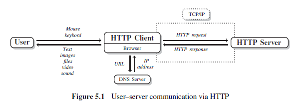

- Most common HTTP requests are GET and POST request to receive and send data

## Accessing Websites

```r
library(rvest)
wikipedia <-read_html(
"https://en.wikipedia.org/wiki/World_Health_Organization_ranking_of_health_systems_in_2000")
class(wikipedia)
```

```
## [1] "xml_document" "xml_node"
```

## Xpath

- Xpath is a query language for XML/HTML documents
- Very useful in locating parts of the HTML document
- Can use Xpath with `html_element` command:

```r
listOfANodes <- html_elements(wikipedia,xpath= '//a[@href]')
listOfANodes[1]
```

```
## {xml_nodeset (1)}
## [1] <a class="mw-jump-link" href="#mw-head">Jump to navigation</a>
```

```r
title <- html_element(wikipedia,xpath = "//title")
html_text(title)
```

```
## [1] "World Health Organization ranking of health systems in 2000 - Wikipedia"
```

## Accessing HTML Elements

```r
section_of_wikipedia <- html_node(wikipedia,
              xpath='//*[@id="mw-content-text"]/div/table')
mytable <- html_table(section_of_wikipedia)
head(mytable)
```

```
## # A tibble: 6 x 7
##   Country  `Attainment of g~ `Attainment of g~ `Attainment of ~ `Health expendi~
##   <chr>                <int>             <int>            <int>            <int>
## 1 Afghani~               164                 0              183              184
## 2 Albania                102               128               86              149
## 3 Algeria                 44                63               56               24
## 4 Andorra                 10                25               17               23
## 5 Angola                 165               178              181              164
## 6 Antigua~                48                58               71               56
## # ... with 2 more variables: Performance / On level of health <int>,
## #   Performance / Overall health system performance <int>
```

## Another Example

- This website has an easier structure: http://varycss.org/groups.html
- Can you identify the table XPath and extract the element on your own?

```r
## url for webpage
varycss <- read_html("http://varycss.org/groups.html")

## locate the table component of the html
groups <- html_node(varycss, xpath = '//table[1]')

## extract the table
mytable2 <- html_table(groups)
```

## Another Example

- Scraping multiple links

```r
aoc <- read_html("https://ocasio-cortez.house.gov/issues")
issues <- html_nodes(aoc, xpath = '//*[(@id = "block-menu-block-section-menu")]//a')
issuetitles <- html_text(issues)
head(issuetitles)
```

```
## [1] "A Just Society"            "Climate Equity Act"
## [3] "Criminal Justice Reform"   "Economic Inequality"
## [5] "Education"                 "Green New Deal Resolution"
```

## Another Example

```r
## We want just the links, so we will use html_attr with href
issuelinks <- html_attr(issues, 'href')
issuelinks[1]
```

```
## [1] "/ajs"
```

```r
issueurls <- paste("https://ocasio-cortez.house.gov", issuelinks, sep="")
## Let's build a dataframe for storage
aocplatform <- data.frame(issues = issuetitles, url = issueurls,
                          text = NA)
```

## Forms

- May need to send information to forms
- Somewhat more involved than simply retrieving websites
- Example: searching firms’ addresses on Google

```r
library(foreign)
library(rvest)
library(xml2)
library(httr)
library(stringr)

firms <- read.csv("d:/users/andrey/dropbox/data/sicss 2021/firms2.csv")[,1]
hq <- c()
```

## Forms

```r
html <- read_html("http://www.google.com")
search <- html_form(html)[[1]]
search <- search %>% html_form_set(
          q = paste(firms[1], "bloomberg",sep=" "),
                                     hl = "en")
```

## Forms

```r
resp <- html_form_submit(search,submit="btnG")
site <- read_html(resp)
html_element(site,"*")
```

```
## {html_node}
## <head>
## [1] <meta charset="UTF-8">\n
## [2] <meta content="/images/branding/googleg/1x/googleg_standard_color_128dp.p ...
## [3] <title>Acciona Energia SA bloomberg - Google Search</title>\n
## [4] <script nonce="YjhUb09pe5pwYArX1icZhA==">(function(){\ndocument.documentE ...
## [5] <style>body{margin:0 auto;max-width:736px;padding:0 8px;}a{color:#1967D2; ...
```

## Locating HTML Elements

- HTML structure can be complicated, but Xpath is very flexible
- Can formulate searches using element-value pairs

```r
  links <- html_elements(site,
          xpath='//a[contains(@href, "bloomberg.com/profile")]')[1] %>%
    html_attr("href")
  print(links)
```

```
## [1] "/url?q=https://www.bloomberg.com/profile/company/100017Z:SM&sa=U&ved=2ahUKEwiwy4PC_JXxAhVfRzABHQhxCjsQFjAAegQIAxAB&usg=AOvVaw3UMSWqp8ZmyFdWax_BslkX"
```

## Regular Expressions

- Need to process link text to make links usable
- Can use Regular Expressions to look for text patterns

```r
s <- str_extract(links,"(?<=q=)(.*?)(?=&sa)")
print(s)
```

```
## [1] "https://www.bloomberg.com/profile/company/100017Z:SM"
```

## Locating, Extracting and Cleaning HTML Elements

```r
 b <- read_html(s)
 hq <- html_text(xml_siblings(
    html_element(b,xpath='//h2[contains(text(),"ADDRESS")]')))
 print(hq)
```

```
## [1] "Avenida Ciudad de la Innovacio\nNavarra, 31621\nSpain"
```

```r
 hq<- str_replace_all(hq,"\n"," ")
 print(hq)
```

```
## [1] "Avenida Ciudad de la Innovacio Navarra, 31621 Spain"
```

## Looping Over Firms

- Putting it all together in a loop
- Need to be prepared for exceptions and error

```
  if(length(links)==0){hq[i] <- NA
  } else {
  s <- str_extract(links,"(?<=q=)(.*?)(?=&sa)")
  ...
```

- Good idea to have some time in between iterations

```
 t <- runif(1,5,10)
  Sys.sleep(t)
```

## Scraping With a Browser

- Some sites are difficult to scrape using HTTP requests
- Javascript and other scripts require user’s interaction with a browser
- RSelenium: simulates a browser that can be controlled via R commands
- Can interact directly with webpage through browser actions: filling forms, clicking buttons, selecting menus, etc.